# CS5801 Coursework Template Proforma

10 December, 2020

# 0. Instructions

*1. Remove the (italicised) guidance text but keep the section headings.*  
*2. Add as many chunks of R code as required.*  
*3. Add descriptions of your analysis plans and explanations of your code and findings. Please be detailed and where you have made choices explain the rationale for them.*  
*4. Write your report using RMarkdown. For guidance see a [helpful blog](https://www.dataquest.io/blog/r-markdown-guide-cheatsheet/#tve-jump-17333da0719) or use the R Markdown cheatsheet which can be accessed from within RStudio by selecting `Help > Cheatsheets > R Markdown Cheat Sheet`.*  
*5. Your report should be clearly and professionally presented with appropriate use of cited external sources. (5 marks)*  
*6. It should also be easy to understand, with well-documented code following the principles of literate programming. (5 marks)*

```r
# Add code here to load any required libraries with `library()`.
# We suggest you use `install.package()` for any required packages externally to this document
# since installation only need be done once.
install.packages("ggplot2")
```

Sometimes this does not work, in which case go to tools>install packages>paste the following under CRAN: ggplot2,dplyr,dbplyr,foreign,ggpubr,xtable,mgcv,tree,validate, lubridate Then load the libraries below

```r
library(ggplot2)
library(dplyr)
library(dbplyr)
library(foreign)
library(ggpubr)
library(xtable)
library(mgcv)
library(tree)
library(validate)
library(lubridate)
library(GGally)
library(PerformanceAnalytics)
```

# 1. Organise and clean the data

## 1.1 Subset the data into the specific dataset allocated

```r
# Code to select the student specific team combination.
# Feel free to change it including the data frame name.
#
# my.2teams.df <- subset(analysis.data, teamID.x=="???" | teamID.x=="???")
BOSLAA = subset(CS5801.data, teamID.x == "BOS" | teamID.x=="LAA")
BOS = subset(CS5801.data, teamID.x == "BOS")
LAA = subset(CS5801.data, teamID.x == "LAA")
```

Only the two teams need to be separated at this stage, but I also decivded to have subsets including only one team each. The reason is that later on, I will probably want to look at each on of them separately. This is because depending on the task at hand, different sized datasets will be more useful. **spoiler alert**, it is useful at the end of part 1.

## 1.2 Data quality analysis

*Provide a description of a comprehensive plan to assess the quality of the data, and document your findings. Include all variables/columns (5 marks) from the data set and provide a full implementation (5 marks). NB even if no data quality issues are identified you should still check and report.*

```r
summary(BOSLAA)
```

```
   playerID            teamID.x        G                R               H
 Length:80          BOS    :42   Min.   :  1.00   Min.   :  0.0   Min.   :  0.00
 Class :character   LAA    :38   1st Qu.: 22.75   1st Qu.:  0.0   1st Qu.:  0.00
 Mode  :character   ALT    : 0   Median : 39.50   Median :  0.0   Median :  2.00
                    ANA    : 0   Mean   : 55.74   Mean   : 17.3   Mean   : 34.98
                    ARI    : 0   3rd Qu.: 75.50   3rd Qu.: 28.0   3rd Qu.: 52.00
                    ATL    : 0   Max.   :159.00   Max.   :104.0   Max.   :196.00
                    (Other): 0
       AB             RBI             weight          height          salary
 Min.   :  0.0   Min.   : -4.00   Min.   :170.0   Min.   :68.00   Min.   :     500
 1st Qu.:  0.0   1st Qu.:  0.00   1st Qu.:195.0   1st Qu.:71.00   1st Qu.:  523436
 Median :  6.0   Median :  0.00   Median :210.0   Median :73.00   Median : 1600000
 Mean   :135.8   Mean   : 16.25   Mean   :208.8   Mean   :72.75   Mean   : 4747898
 3rd Qu.:227.5   3rd Qu.: 26.00   3rd Qu.:220.0   3rd Qu.:75.00   3rd Qu.: 6568750
 Max.   :630.0   Max.   :108.00   Max.   :268.0   Max.   :79.00   Max.   :24000000

   birthDate          career.length     bats        age           hit.ind
 Min.   :1975-04-03   Min.   : 0.2902   B: 4   Min.   :22.23   Min.   :0.00
 1st Qu.:1983-08-15   1st Qu.: 2.3313   L:20   1st Qu.:26.65   1st Qu.:0.00
 Median :1985-07-30   Median : 4.5763   R:56   Median :29.69   Median :1.00
 Mean   :1986-03-05   Mean   : 5.4564          Mean   :29.38   Mean   :0.55
 3rd Qu.:1988-05-30   3rd Qu.: 7.8980          3rd Qu.:31.48   3rd Qu.:1.00
 Max.   :2002-06-17   Max.   :35.4127          Max.   :39.75   Max.   :1.00
```

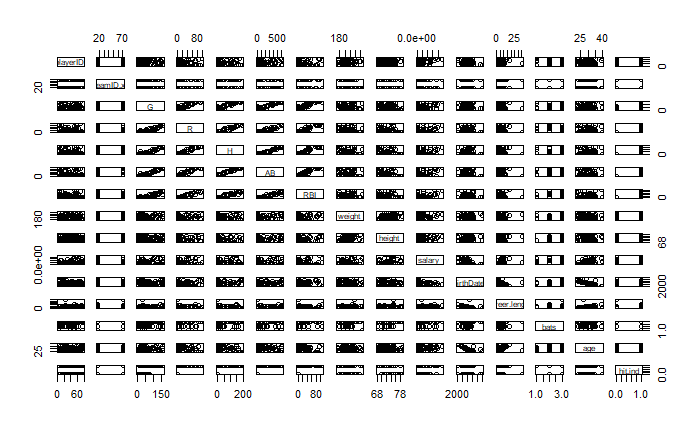

```r
plot(BOSLAA)
```

It contains 15 variables. They are as follows: 1 - playerID 2 - teamID.x 3 - R 4 - G 5 - H 6 - AB 7 - RBI 8 - weight 9 - height 10 - salary 11 - birthDate 12 - career.legth 13 - bats 14 - age 15 - hit.ind

structure() and glimpse() are good here. This is because they tell me the size and appearance on the values as well as their type. I have mostly numeric (int and dbl) data, but also factors, characters, and a date

```r
structure(BOSLAA)
```

|  | playerID | teamID.x | G | R | H | AB | RBI | weight | height | salary | birthDate | career.length | bats | age | hit.ind |
| --- | --- | --- | --- | --- | --- | --- | --- | --- | --- | --- | --- | --- | --- | --- | --- |
| 16 | alvarjo02 | LAA | 64 | 0 | 0 | 0 | 0 | 180 | 71 | 5.09500e+05 | 1989-05-06 | 1.5633128 | L | 25.65640 | 0 |
| 37 | aybarer01 | LAA | 156 | 74 | 161 | 597 | 44 | 195 | 70 | 8.50000e+06 | 1984-01-14 | 8.6297057 | B | 30.96509 | 1 |
| 45 | barnema01 | BOS | 32 | 0 | 0 | 0 | 0 | 210 | 76 | 5.08500e+05 | 1990-06-17 | 0.3121150 | R | 24.54209 | 0 |
| 64 | bettsmo01 | BOS | 145 | 92 | 174 | 597 | 77 | 180 | 69 | 5.14500e+05 | 1992-10-07 | 0.5092402 | R | 22.23409 | 1 |
| 72 | bogaexa01 | BOS | 156 | 84 | 196 | 613 | 81 | 210 | 73 | 5.43000e+05 | 1992-10-01 | 1.3661875 | R | 22.25051 | 1 |
| 81 | bradlja02 | BOS | 74 | 43 | 55 | 221 | 43 | 200 | 70 | 5.28000e+05 | 1990-04-19 | 1.7522245 | L | 24.70363 | 1 |
| 84 | breslcr01 | BOS | 45 | 0 | 0 | 0 | 0 | 190 | 72 | 2.00000e+06 | 1980-08-08 | 9.4428474 | L | 34.39836 | 0 |
| 93 | buchhcl01 | BOS | 18 | 0 | 0 | 6 | 0 | 190 | 75 | 1.20000e+07 | 1984-08-14 | 7.3757700 | L | 30.38193 | 0 |
| 97 | buterdr01 | LAA | 10 | 3 | 4 | 21 | 0 | 205 | 73 | 9.87500e+05 | 1983-08-09 | 4.7310062 | R | 31.39767 | 1 |
| 111 | calhoko01 | LAA | 159 | 78 | 161 | 630 | 83 | 215 | 70 | 5.37500e+05 | 1987-10-14 | 2.6119097 | L | 27.21697 | 1 |

[output cut: 70 more lines]

```r
glimpse(BOSLAA)
```

```
Rows: 80
Columns: 15
$ playerID      <chr> "alvarjo02", "aybarer01", "barnema01", "bettsmo01", "bogaex...
$ teamID.x      <fct> LAA, LAA, BOS, BOS, BOS, BOS, BOS, BOS, LAA, LAA, BOS, BOS,...
$ G             <int> 64, 156, 32, 145, 156, 74, 45, 18, 10, 159, 80, 2, 5, 55, 3...
$ R             <int> 0, 74, 0, 92, 84, 43, 0, 0, 3, 78, 35, 0, 0, 10, 6, 37, 23,...
$ H             <int> 0, 161, 0, 174, 196, 55, 0, 0, 4, 161, 69, 0, 0, 13, 12, 99...
$ AB            <int> 0, 597, 0, 597, 613, 221, 0, 6, 21, 630, 273, 4, 0, 69, 79,...
$ RBI           <int> 0, 44, 0, 77, 81, 43, 0, 0, 0, 83, 29, 0, 0, 2, 3, 51, 25, ...
$ weight        <int> 180, 195, 210, 180, 210, 200, 190, 190, 205, 215, 195, 220,...
$ height        <int> 71, 70, 76, 69, 73, 70, 72, 75, 73, 70, 69, 75, 74, 69, 74,...
$ salary        <dbl> 509500, 8500000, 508500, 514500, 543000, 528000, 2000000, 1...
$ birthDate     <date> 1989-05-06, 1984-01-14, 1990-06-17, 1992-10-07, 1992-10-01...
$ career.length <dbl> 1.5633128, 8.6297057, 0.3121150, 0.5092402, 1.3661875, 1.75...
$ bats          <fct> L, B, R, R, R, L, L, L, R, L, R, L, R, R, R, R, L, L, R, R,...
$ age           <dbl> 25.65640, 30.96509, 24.54209, 22.23409, 22.25051, 24.70363,...
$ hit.ind       <dbl> 0, 1, 0, 1, 1, 1, 0, 0, 1, 1, 1, 0, 0, 1, 1, 1, 1, 1, 1, 1,...
```

I will also check for missing values. Luckily there are none here. Because the test prints a maximum number of values, splitting the subset into two (divided by team) allowed for all 80 rows to be visible. As can be seen, there is not a single missing value.

```r
is.na(BOS)
```

```
    playerID teamID.x     G     R     H    AB   RBI weight height salary birthDate
45     FALSE    FALSE FALSE FALSE FALSE FALSE FALSE  FALSE  FALSE  FALSE     FALSE
64     FALSE    FALSE FALSE FALSE FALSE FALSE FALSE  FALSE  FALSE  FALSE     FALSE
72     FALSE    FALSE FALSE FALSE FALSE FALSE FALSE  FALSE  FALSE  FALSE     FALSE
81     FALSE    FALSE FALSE FALSE FALSE FALSE FALSE  FALSE  FALSE  FALSE     FALSE
84     FALSE    FALSE FALSE FALSE FALSE FALSE FALSE  FALSE  FALSE  FALSE     FALSE
93     FALSE    FALSE FALSE FALSE FALSE FALSE FALSE  FALSE  FALSE  FALSE     FALSE
127    FALSE    FALSE FALSE FALSE FALSE FALSE FALSE  FALSE  FALSE  FALSE     FALSE
133    FALSE    FALSE FALSE FALSE FALSE FALSE FALSE  FALSE  FALSE  FALSE     FALSE
169    FALSE    FALSE FALSE FALSE FALSE FALSE FALSE  FALSE  FALSE  FALSE     FALSE
177    FALSE    FALSE FALSE FALSE FALSE FALSE FALSE  FALSE  FALSE  FALSE     FALSE
196    FALSE    FALSE FALSE FALSE FALSE FALSE FALSE  FALSE  FALSE  FALSE     FALSE
349    FALSE    FALSE FALSE FALSE FALSE FALSE FALSE  FALSE  FALSE  FALSE     FALSE
368    FALSE    FALSE FALSE FALSE FALSE FALSE FALSE  FALSE  FALSE  FALSE     FALSE
383    FALSE    FALSE FALSE FALSE FALSE FALSE FALSE  FALSE  FALSE  FALSE     FALSE
```

[output cut: 71 more lines]

```r
is.na(LAA)
```

```
    playerID teamID.x     G     R     H    AB   RBI weight height salary birthDate
16     FALSE    FALSE FALSE FALSE FALSE FALSE FALSE  FALSE  FALSE  FALSE     FALSE
37     FALSE    FALSE FALSE FALSE FALSE FALSE FALSE  FALSE  FALSE  FALSE     FALSE
97     FALSE    FALSE FALSE FALSE FALSE FALSE FALSE  FALSE  FALSE  FALSE     FALSE
111    FALSE    FALSE FALSE FALSE FALSE FALSE FALSE  FALSE  FALSE  FALSE     FALSE
175    FALSE    FALSE FALSE FALSE FALSE FALSE FALSE  FALSE  FALSE  FALSE     FALSE
182    FALSE    FALSE FALSE FALSE FALSE FALSE FALSE  FALSE  FALSE  FALSE     FALSE
204    FALSE    FALSE FALSE FALSE FALSE FALSE FALSE  FALSE  FALSE  FALSE     FALSE
275    FALSE    FALSE FALSE FALSE FALSE FALSE FALSE  FALSE  FALSE  FALSE     FALSE
296    FALSE    FALSE FALSE FALSE FALSE FALSE FALSE  FALSE  FALSE  FALSE     FALSE
299    FALSE    FALSE FALSE FALSE FALSE FALSE FALSE  FALSE  FALSE  FALSE     FALSE
399    FALSE    FALSE FALSE FALSE FALSE FALSE FALSE  FALSE  FALSE  FALSE     FALSE
436    FALSE    FALSE FALSE FALSE FALSE FALSE FALSE  FALSE  FALSE  FALSE     FALSE
470    FALSE    FALSE FALSE FALSE FALSE FALSE FALSE  FALSE  FALSE  FALSE     FALSE
560    FALSE    FALSE FALSE FALSE FALSE FALSE FALSE  FALSE  FALSE  FALSE     FALSE
```

[output cut: 63 more lines]

## 1.3 Data cleaning

*Explain any data quality issues found in 1.2 (5 marks), justify and document the responses made (if any) (5 marks).*

The dataset name will be renamed to League, because it carries more meaning. not only this, but later on, when comparing the two teams to the league as a whole, there will be fewer formatting issues. The reason is that punctuation in the wrong places can impact things, and having punctuation in the middle of a name can also be confusing to the reader as it could look like it has a purpose beyond beying a character in a name. It is also a personal stylistic choice. I will rename some collumns as well, so that I can better understand what I am loking at at a glance, but also for the reasons above. While renaming, I can also separate it by team. While it looks like a lot of work, this will save a lot of time later on. It also means that my definitions are, for the large part, in one place.

It contains 15 variables. They will be renamed as follows: platerID teamID.x R - Runs G - Games H - Hits AB - AtBat RBI - RunsBatted weight height salary birthDate - Birth career.length - Career bats age hit.ind - SeasonHit. I do not know what hit.ind means, but it represents whether a player had a hit that season.It has a Bernoulli disctribution, which has a binary distribution. SeasonHit 1 or 0 basically turns it into a yes/no question which makes more intuitive sense to me. The rest will simply be capitalised for consistent formatting

```r
League = CS5801.data
League %>%
  rename(
    Team = teamID.x,
    Runs = R,
    Games = G,
    Hits = H,
    AtBat = AB,
    RunsBatted = RBI,
    Weight = weight,
    Height = height,
    Salary = salary,
    Birth = birthDate,
    Career = career.length,
    Bats = bats,
    Age = age,
    SeasonHit = hit.ind
    )
```

| playerID | Team | Games | Runs | Hits | AtBat | RunsBatted | Weight | Height | Salary | Birth | Career | Bats | Age | SeasonHit |
| --- | --- | --- | --- | --- | --- | --- | --- | --- | --- | --- | --- | --- | --- | --- |
| abadfe01 | OAK | 62 | 0 | 0 | 0 | 0 | 220 | 73 | 1.087500e+06 | 1985-12-17 | 4.4298426 | L | 29.04038 | 0 |
| abreujo02 | CHA | 154 | 88 | 178 | 613 | 101 | 255 | 75 | 8.666000e+06 | 1987-01-29 | 0.7556468 | R | 27.92334 | 1 |
| ackledu01 | NYA | 23 | 6 | 15 | 52 | 11 | 205 | 73 | 2.600000e+06 | 1988-02-26 | 3.5427789 | L | 26.84736 | 1 |
| ackledu01 | SEA | 85 | 22 | 40 | 186 | 19 | 205 | 73 | 2.600000e+06 | 1988-02-26 | 3.5427789 | L | 26.84736 | 1 |
| adamsau01 | CLE | 28 | 0 | 0 | 1 | 0 | 205 | 71 | 5.077000e+05 | 1986-08-19 | 0.4736482 | R | 28.36961 | 0 |
| adamsma01 | SLN | 60 | 14 | 42 | 175 | 24 | 245 | 75 | 5.340000e+05 | 1988-08-31 | 2.6173854 | L | 26.33539 | 1 |
| affelje01 | SFN | 52 | 0 | 0 | 2 | 0 | 225 | 76 | 6.000000e+06 | 1979-06-06 | 12.7392197 | L | 35.57290 | 0 |
| ahmedni01 | ARI | 134 | 49 | 95 | 421 | 34 | 195 | 74 | 5.085000e+05 | 1990-03-15 | 0.5092402 | R | 24.79945 | 1 |
| alberma01 | CHA | 30 | 0 | 0 | 0 | 0 | 225 | 73 | 1.500000e+06 | 1983-01-20 | 8.4380561 | L | 31.94798 | 0 |
| albural01 | DET | 67 | 0 | 0 | 0 | 0 | 195 | 72 | 1.725000e+06 | 1986-06-10 | 3.7152635 | R | 28.56126 | 0 |

[output cut: 958 more lines]

```r
BOSLAA %>%
  rename(
    Team = teamID.x,
    Runs = R,
    Games = G,
    Hits = H,
    AtBat = AB,
    RunsBatted = RBI,
    Weight = weight,
    Height = height,
    Salary = salary,
    Birth = birthDate,
    Career = career.length,
    Bats = bats,
    Age = age,
    SeasonHit = hit.ind
    )
```

|  | playerID | Team | Games | Runs | Hits | AtBat | RunsBatted | Weight | Height | Salary | Birth | Career | Bats | Age | SeasonHit |
| --- | --- | --- | --- | --- | --- | --- | --- | --- | --- | --- | --- | --- | --- | --- | --- |
| 16 | alvarjo02 | LAA | 64 | 0 | 0 | 0 | 0 | 180 | 71 | 5.09500e+05 | 1989-05-06 | 1.5633128 | L | 25.65640 | 0 |
| 37 | aybarer01 | LAA | 156 | 74 | 161 | 597 | 44 | 195 | 70 | 8.50000e+06 | 1984-01-14 | 8.6297057 | B | 30.96509 | 1 |
| 45 | barnema01 | BOS | 32 | 0 | 0 | 0 | 0 | 210 | 76 | 5.08500e+05 | 1990-06-17 | 0.3121150 | R | 24.54209 | 0 |
| 64 | bettsmo01 | BOS | 145 | 92 | 174 | 597 | 77 | 180 | 69 | 5.14500e+05 | 1992-10-07 | 0.5092402 | R | 22.23409 | 1 |
| 72 | bogaexa01 | BOS | 156 | 84 | 196 | 613 | 81 | 210 | 73 | 5.43000e+05 | 1992-10-01 | 1.3661875 | R | 22.25051 | 1 |
| 81 | bradlja02 | BOS | 74 | 43 | 55 | 221 | 43 | 200 | 70 | 5.28000e+05 | 1990-04-19 | 1.7522245 | L | 24.70363 | 1 |
| 84 | breslcr01 | BOS | 45 | 0 | 0 | 0 | 0 | 190 | 72 | 2.00000e+06 | 1980-08-08 | 9.4428474 | L | 34.39836 | 0 |
| 93 | buchhcl01 | BOS | 18 | 0 | 0 | 6 | 0 | 190 | 75 | 1.20000e+07 | 1984-08-14 | 7.3757700 | L | 30.38193 | 0 |
| 97 | buterdr01 | LAA | 10 | 3 | 4 | 21 | 0 | 205 | 73 | 9.87500e+05 | 1983-08-09 | 4.7310062 | R | 31.39767 | 1 |
| 111 | calhoko01 | LAA | 159 | 78 | 161 | 630 | 83 | 215 | 70 | 5.37500e+05 | 1987-10-14 | 2.6119097 | L | 27.21697 | 1 |

[output cut: 70 more lines]

```r
BOS %>%
  rename(
    Team = teamID.x,
    Runs = R,
    Games = G,
    Hits = H,
    AtBat = AB,
    RunsBatted = RBI,
    Weight = weight,
    Height = height,
    Salary = salary,
    Birth = birthDate,
    Career = career.length,
    Bats = bats,
    Age = age,
    SeasonHit = hit.ind
    )
```

|  | playerID | Team | Games | Runs | Hits | AtBat | RunsBatted | Weight | Height | Salary | Birth | Career | Bats | Age | SeasonHit |
| --- | --- | --- | --- | --- | --- | --- | --- | --- | --- | --- | --- | --- | --- | --- | --- |
| 45 | barnema01 | BOS | 32 | 0 | 0 | 0 | 0 | 210 | 76 | 5.08500e+05 | 1990-06-17 | 0.3121150 | R | 24.54209 | 0 |
| 64 | bettsmo01 | BOS | 145 | 92 | 174 | 597 | 77 | 180 | 69 | 5.14500e+05 | 1992-10-07 | 0.5092402 | R | 22.23409 | 1 |
| 72 | bogaexa01 | BOS | 156 | 84 | 196 | 613 | 81 | 210 | 73 | 5.43000e+05 | 1992-10-01 | 1.3661875 | R | 22.25051 | 1 |
| 81 | bradlja02 | BOS | 74 | 43 | 55 | 221 | 43 | 200 | 70 | 5.28000e+05 | 1990-04-19 | 1.7522245 | L | 24.70363 | 1 |
| 84 | breslcr01 | BOS | 45 | 0 | 0 | 0 | 0 | 190 | 72 | 2.00000e+06 | 1980-08-08 | 9.4428474 | L | 34.39836 | 0 |
| 93 | buchhcl01 | BOS | 18 | 0 | 0 | 6 | 0 | 190 | 75 | 1.20000e+07 | 1984-08-14 | 7.3757700 | L | 30.38193 | 0 |
| 127 | castiru01 | BOS | 80 | 35 | 69 | 273 | 29 | 195 | 69 | 1.12710e+07 | 1987-07-09 | 0.2902122 | R | 27.48255 | 1 |
| 133 | cecchga01 | BOS | 2 | 0 | 0 | 4 | 0 | 220 | 75 | 5.08500e+05 | 1991-04-20 | 0.5859001 | L | 23.70157 | 0 |
| 169 | cookry01 | BOS | 5 | 0 | 0 | 0 | 0 | 215 | 74 | 1.40000e+06 | 1987-06-30 | 3.4524298 | R | 27.50719 | 0 |
| 177 | craigal01 | BOS | 36 | 6 | 12 | 79 | 3 | 215 | 74 | 5.50000e+06 | 1984-07-18 | 4.7337440 | R | 30.45585 | 1 |

[output cut: 32 more lines]

```r
LAA %>%
  rename(
    Team = teamID.x,
    Runs = R,
    Games = G,
    Hits = H,
    AtBat = AB,
    RunsBatted = RBI,
    Weight = weight,
    Height = height,
    Salary = salary,
    Birth = birthDate,
    Career = career.length,
    Bats = bats,
    Age = age,
    SeasonHit = hit.ind
    )
```

|  | playerID | Team | Games | Runs | Hits | AtBat | RunsBatted | Weight | Height | Salary | Birth | Career | Bats | Age | SeasonHit |
| --- | --- | --- | --- | --- | --- | --- | --- | --- | --- | --- | --- | --- | --- | --- | --- |
| 16 | alvarjo02 | LAA | 64 | 0 | 0 | 0 | 0 | 180 | 71 | 5.09500e+05 | 1989-05-06 | 1.5633128 | L | 25.65640 | 0 |
| 37 | aybarer01 | LAA | 156 | 74 | 161 | 597 | 44 | 195 | 70 | 8.50000e+06 | 1984-01-14 | 8.6297057 | B | 30.96509 | 1 |
| 97 | buterdr01 | LAA | 10 | 3 | 4 | 21 | 0 | 205 | 73 | 9.87500e+05 | 1983-08-09 | 4.7310062 | R | 31.39767 | 1 |
| 111 | calhoko01 | LAA | 159 | 78 | 161 | 630 | 83 | 215 | 70 | 5.37500e+05 | 1987-10-14 | 2.6119097 | L | 27.21697 | 1 |
| 175 | cowgico01 | LAA | 55 | 10 | 13 | 69 | 2 | 190 | 69 | 9.95000e+05 | 1986-05-22 | 3.4360027 | R | 28.61328 | 1 |
| 182 | croncj01 | LAA | 113 | 37 | 99 | 378 | 51 | 235 | 76 | 5.12500e+05 | 1990-01-05 | 0.6652977 | R | 24.98836 | 1 |
| 204 | dejesda01 | LAA | 30 | 3 | 7 | 56 | 4 | 190 | 71 | 5.00000e+06 | 1979-12-20 | 11.3319644 | L | 35.03354 | 1 |
| 275 | freesda01 | LAA | 121 | 53 | 109 | 424 | 56 | 213 | 74 | 6.42500e+06 | 1983-04-28 | 5.7385352 | R | 31.67967 | 1 |
| 296 | giavojo01 | LAA | 129 | 51 | 123 | 453 | 49 | 185 | 68 | 5.16250e+05 | 1987-07-10 | 3.4086242 | R | 27.47981 | 1 |
| 299 | gillaco01 | LAA | 17 | 4 | 13 | 64 | 9 | 195 | 73 | 5.50000e+05 | 1987-07-18 | 6.3107461 | L | 27.45791 | 1 |

[output cut: 28 more lines]

Here I am making subests of everything so that I do not have to later. Having this in one place means that I need to look in fewer places when making changes.

```r
League = CS5801.data
#1
LeagueGames = League$G
BOSLAAGames = BOSLAA$G
BOSGames = BOS$G
LAAGames = LAA$G
#2
LeagueRuns = League$R
BOSLAARuns = BOSLAA$R
BOSRuns = BOS$R
LAARuns = LAA$R
#3
LeagueHits = League$H
BOSLAAHits = BOSLAA$H
BOSHits = BOS$H
LAAHits = LAA$H
#4
LeagueAtBat = League$AB
BOSLAAAtBat = BOSLAA$AB
BOSAtBat = BOS$AB
LAAAtBat = LAA$AB
#5
LeagueRunsBatted = League$RBI
BOSLAARunsBatted = BOSLAA$RBI
BOSRunsBatted = BOS$RBI
LAARunsBatted = LAA$RBI
#6
LeagueWeight = League$weight
BOSLAAWeight = BOSLAA$weight
BOSWeight = BOS$weight
LAAWeight = LAA$weight
#7
LeagueHeight = League$height
BOSLAAHeight = BOSLAA$height
BOSHeight = BOS$height
LAAHeight = LAA$height
#8
LeagueSalary = League$salary
BOSLAASalary = BOSLAA$salary
BOSSalary = BOS$salary
LAASalary = LAA$salary
#9
LeagueBirth = League$birthDate
BOSLAABirth = BOSLAA$birthDate
BOSBirth = BOS$birthDate
LAABirth = LAA$birthDate
#10
LeagueCareer = League$career.length
BOSLAACareer = BOSLAA$career.length
BOSCareer = BOS$career.length
LAACareer = LAA$career.length
#11
LeagueBats = League$bats
BOSLAABats = BOSLAA$bats
BOSBats = BOS$bats
LAABats = LAA$bats
#12
LeagueAge = League$age
BOSLAAAge = BOSLAA$age
BOSAge = BOS$age
LAAAge = LAA$age
#13
LeagueSeasonHit = League$hit.ind
BOSLAASeasonHit = BOSLAA$hit.ind
BOSSeasonHit = BOS$hit.ind
LAASeasonHit = LAA$hit.ind
#14
LeagueplayerID = League$playerID
BOSLAAplayerID = BOSLAA$playerID
BOSplayerID = BOS$playerID
LAAplayerID = LAA$playerID
```

Before taking any further steps, it is clear that some values make no sense. For example, BOS has a player with a negative RBI. It is not possible to run a negative number of runs. check_that() is very useful as it allows me to create rules and check them. Rules such as valid answers, or logical answers. This is first done for the league as a whole, going down in number.

I might have to turn these subsets back into dataframes, but at least I understand what the figures mean. This will be important when analysing everything later. It might seem like a good idea to check for duplicate players here. This is not clever. The reason is that the same player can play for multiple teams.

```r
## Data quality checking for the whole league
summary(League)
```

```
   playerID            teamID.x         G                R                H
 Length:968         BOS    : 42   Min.   :-38.00   Min.   :-85.00   Min.   :  0.00
 Class :character   TEX    : 42   1st Qu.: 26.00   1st Qu.:  0.00   1st Qu.:  0.00
 Mode  :character   LAN    : 41   Median : 49.00   Median :  3.00   Median :  7.00
                    NYN    : 40   Mean   : 62.78   Mean   : 19.31   Mean   : 39.86
                    CHN    : 39   3rd Qu.: 96.25   3rd Qu.: 34.00   3rd Qu.: 69.00
                    PIT    : 39   Max.   :162.00   Max.   :122.00   Max.   :205.00
                    (Other):725
       AB             RBI             weight        height          salary
 Min.   :  0.0   Min.   :-21.00   Min.   : 80   Min.   :38.00   Min.   :     500
 1st Qu.:  0.0   1st Qu.:  0.00   1st Qu.:200   1st Qu.:72.00   1st Qu.:  524375
 Median : 50.0   Median :  3.00   Median :210   Median :74.00   Median : 2000000
 Mean   :155.9   Mean   : 18.55   Mean   :214   Mean   :73.58   Mean   : 4348484
 3rd Qu.:288.2   3rd Qu.: 31.00   3rd Qu.:225   3rd Qu.:75.00   3rd Qu.: 6000000
 Max.   :638.0   Max.   :130.00   Max.   :585   Max.   :95.00   Max.   :32571000

   birthDate          career.length     bats         age           hit.ind
 Min.   :1972-12-21   Min.   :-0.2847   B: 77   Min.   :20.91   Min.   :0.000
 1st Qu.:1983-08-07   1st Qu.: 2.5154   L:285   1st Qu.:26.54   1st Qu.:0.000
 Median :1986-03-19   Median : 4.5886   R:606   Median :28.82   Median :1.000
 Mean   :1985-11-24   Mean   : 5.5309           Mean   :29.18   Mean   :0.626
 3rd Qu.:1988-07-14   3rd Qu.: 8.3101           3rd Qu.:31.42   3rd Qu.:1.000
 Max.   :2003-09-08   Max.   :38.4408           Max.   :42.03   Max.   :1.000
```

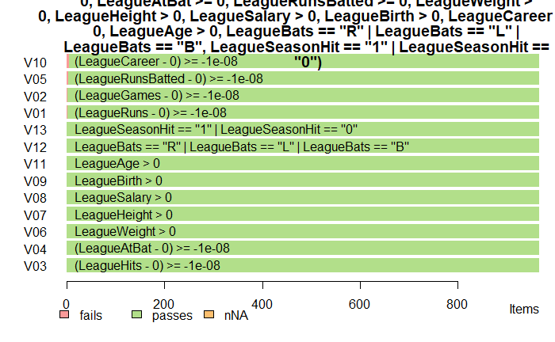

```r
LeagueCheck <- check_that(League,
                          LeagueRuns>= 0,
                          LeagueGames>= 0,
                          LeagueHits >= 0,
                          LeagueAtBat >= 0,
                          LeagueRunsBatted >= 0,
                          LeagueWeight > 0,
                          LeagueHeight > 0,
                          LeagueSalary > 0,
                          LeagueBirth > 0,
                          LeagueCareer >= 0,
                          LeagueAge > 0,
                          LeagueBats == "R" | LeagueBats == "L" | LeagueBats == "B",
                          LeagueSeasonHit == "1" | LeagueSeasonHit == "0")
#Looking for duplicate team namtes
# Produce a bar chart of the quality rule failures
barplot(LeagueCheck)
```

I see very quickly that there are four areas where the rules were broken. This is because they are negative, and in this case any negative values are a physical impossiblity. These four are: LeagueCareer LeagueRunsBatted LeagueGames LeagueRuns These foud have at least one entry which is negative.

Now I need to see whether they are present in either team:

```r
summary(BOSLAA)
```

```
   playerID            teamID.x        G                R               H
 Length:80          BOS    :42   Min.   :  1.00   Min.   :  0.0   Min.   :  0.00
 Class :character   LAA    :38   1st Qu.: 22.75   1st Qu.:  0.0   1st Qu.:  0.00
 Mode  :character   ALT    : 0   Median : 39.50   Median :  0.0   Median :  2.00
                    ANA    : 0   Mean   : 55.74   Mean   : 17.3   Mean   : 34.98
                    ARI    : 0   3rd Qu.: 75.50   3rd Qu.: 28.0   3rd Qu.: 52.00
                    ATL    : 0   Max.   :159.00   Max.   :104.0   Max.   :196.00
                    (Other): 0
       AB             RBI             weight          height          salary
 Min.   :  0.0   Min.   : -4.00   Min.   :170.0   Min.   :68.00   Min.   :     500
 1st Qu.:  0.0   1st Qu.:  0.00   1st Qu.:195.0   1st Qu.:71.00   1st Qu.:  523436
 Median :  6.0   Median :  0.00   Median :210.0   Median :73.00   Median : 1600000
 Mean   :135.8   Mean   : 16.25   Mean   :208.8   Mean   :72.75   Mean   : 4747898
 3rd Qu.:227.5   3rd Qu.: 26.00   3rd Qu.:220.0   3rd Qu.:75.00   3rd Qu.: 6568750
 Max.   :630.0   Max.   :108.00   Max.   :268.0   Max.   :79.00   Max.   :24000000

   birthDate          career.length     bats        age           hit.ind
 Min.   :1975-04-03   Min.   : 0.2902   B: 4   Min.   :22.23   Min.   :0.00
 1st Qu.:1983-08-15   1st Qu.: 2.3313   L:20   1st Qu.:26.65   1st Qu.:0.00
 Median :1985-07-30   Median : 4.5763   R:56   Median :29.69   Median :1.00
 Mean   :1986-03-05   Mean   : 5.4564          Mean   :29.38   Mean   :0.55
 3rd Qu.:1988-05-30   3rd Qu.: 7.8980          3rd Qu.:31.48   3rd Qu.:1.00
 Max.   :2002-06-17   Max.   :35.4127          Max.   :39.75   Max.   :1.00
```

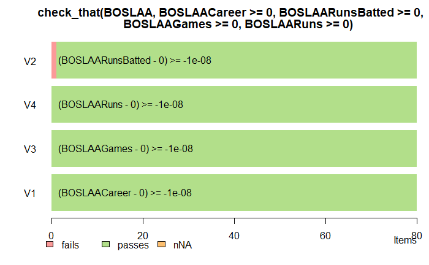

```r
BOSLAACheck <- check_that(BOSLAA,
                          BOSLAACareer>= 0,
                          BOSLAARunsBatted>= 0,
                          BOSLAAGames >= 0,
                          BOSLAARuns >= 0)

# Produce a bar chart of the quality rule failures. I need to turn it into a dataframe
barplot(BOSLAACheck)
```

Here I see that there is one negative RBI. This would appear to be the only problematic value at this stage.

```r
LAACheck <- check_that(LAA,
                          LAARunsBatted>= 0)

barplot(LAACheck)

BOSCheck <- check_that(BOS,

                          BOSRunsBatted>= round(0))
barplot(BOSCheck)
BOSCheckDF =  as.data.frame(BOSCheck)
#let's look at the problem player
ProblemPlayer <- subset(BOSCheckDF, value ==FALSE)
ProblemPlayer
#I have located the player but not identified it
```

[output not shown]

The RBI problem is in Boston. This error could have various causes. I have no way of telling the true value at this stage, however.

Now to identify the duplicate playeys.

```r
BOSDoubles = duplicated(BOSplayerID)
table(BOSDoubles)
```

```
BOSDoubles
FALSE  TRUE
   41     1
```

```r
LAADoubles = duplicated(LAAplayerID)
table(LAADoubles)
```

```
LAADoubles
FALSE  TRUE
   37     1
```

Each team seems to have a duplicate player. By looking at the dataframe itself, Both are indeed duplicated. BOS has pedrodu01, and LAA has richaga01.

Now to remove the duplicated player from each team. this will be done on each team individually, this is because one player could have played on both teams in the same year.

```r
#I need to be careful to only remove duplicates in terms of name, and nothing else.
BOSClean <- BOS[!duplicated(BOS$playerID), ]
LAAClean <- LAA[!duplicated(LAA$playerID), ]
BOSClean
```

|  | playerID | teamID.x | G | R | H | AB | RBI | weight | height | salary | birthDate | career.length | bats | age | hit.ind |
| --- | --- | --- | --- | --- | --- | --- | --- | --- | --- | --- | --- | --- | --- | --- | --- |
| 45 | barnema01 | BOS | 32 | 0 | 0 | 0 | 0 | 210 | 76 | 5.08500e+05 | 1990-06-17 | 0.3121150 | R | 24.54209 | 0 |
| 64 | bettsmo01 | BOS | 145 | 92 | 174 | 597 | 77 | 180 | 69 | 5.14500e+05 | 1992-10-07 | 0.5092402 | R | 22.23409 | 1 |
| 72 | bogaexa01 | BOS | 156 | 84 | 196 | 613 | 81 | 210 | 73 | 5.43000e+05 | 1992-10-01 | 1.3661875 | R | 22.25051 | 1 |
| 81 | bradlja02 | BOS | 74 | 43 | 55 | 221 | 43 | 200 | 70 | 5.28000e+05 | 1990-04-19 | 1.7522245 | L | 24.70363 | 1 |
| 84 | breslcr01 | BOS | 45 | 0 | 0 | 0 | 0 | 190 | 72 | 2.00000e+06 | 1980-08-08 | 9.4428474 | L | 34.39836 | 0 |
| 93 | buchhcl01 | BOS | 18 | 0 | 0 | 6 | 0 | 190 | 75 | 1.20000e+07 | 1984-08-14 | 7.3757700 | L | 30.38193 | 0 |
| 127 | castiru01 | BOS | 80 | 35 | 69 | 273 | 29 | 195 | 69 | 1.12710e+07 | 1987-07-09 | 0.2902122 | R | 27.48255 | 1 |
| 133 | cecchga01 | BOS | 2 | 0 | 0 | 4 | 0 | 220 | 75 | 5.08500e+05 | 1991-04-20 | 0.5859001 | L | 23.70157 | 0 |
| 169 | cookry01 | BOS | 5 | 0 | 0 | 0 | 0 | 215 | 74 | 1.40000e+06 | 1987-06-30 | 3.4524298 | R | 27.50719 | 0 |
| 177 | craigal01 | BOS | 36 | 6 | 12 | 79 | 3 | 215 | 74 | 5.50000e+06 | 1984-07-18 | 4.7337440 | R | 30.45585 | 1 |

[output cut: 31 more lines]

```r
LAAClean
```

|  | playerID | teamID.x | G | R | H | AB | RBI | weight | height | salary | birthDate | career.length | bats | age | hit.ind |
| --- | --- | --- | --- | --- | --- | --- | --- | --- | --- | --- | --- | --- | --- | --- | --- |
| 16 | alvarjo02 | LAA | 64 | 0 | 0 | 0 | 0 | 180 | 71 | 5.09500e+05 | 1989-05-06 | 1.5633128 | L | 25.65640 | 0 |
| 37 | aybarer01 | LAA | 156 | 74 | 161 | 597 | 44 | 195 | 70 | 8.50000e+06 | 1984-01-14 | 8.6297057 | B | 30.96509 | 1 |
| 97 | buterdr01 | LAA | 10 | 3 | 4 | 21 | 0 | 205 | 73 | 9.87500e+05 | 1983-08-09 | 4.7310062 | R | 31.39767 | 1 |
| 111 | calhoko01 | LAA | 159 | 78 | 161 | 630 | 83 | 215 | 70 | 5.37500e+05 | 1987-10-14 | 2.6119097 | L | 27.21697 | 1 |
| 175 | cowgico01 | LAA | 55 | 10 | 13 | 69 | 2 | 190 | 69 | 9.95000e+05 | 1986-05-22 | 3.4360027 | R | 28.61328 | 1 |
| 182 | croncj01 | LAA | 113 | 37 | 99 | 378 | 51 | 235 | 76 | 5.12500e+05 | 1990-01-05 | 0.6652977 | R | 24.98836 | 1 |
| 204 | dejesda01 | LAA | 30 | 3 | 7 | 56 | 4 | 190 | 71 | 5.00000e+06 | 1979-12-20 | 11.3319644 | L | 35.03354 | 1 |
| 275 | freesda01 | LAA | 121 | 53 | 109 | 424 | 56 | 213 | 74 | 6.42500e+06 | 1983-04-28 | 5.7385352 | R | 31.67967 | 1 |
| 296 | giavojo01 | LAA | 129 | 51 | 123 | 453 | 49 | 185 | 68 | 5.16250e+05 | 1987-07-10 | 3.4086242 | R | 27.47981 | 1 |
| 299 | gillaco01 | LAA | 17 | 4 | 13 | 64 | 9 | 195 | 73 | 5.50000e+05 | 1987-07-18 | 6.3107461 | L | 27.45791 | 1 |

[output cut: 27 more lines]

```r
BOSCleanDoubles = duplicated(BOSClean$playerID)
table(BOSCleanDoubles)
```

```
BOSCleanDoubles
FALSE
   41
```

```r
LAACleanDoubles = duplicated(LAAClean$playerID)
table(LAACleanDoubles)
```

```
LAACleanDoubles
FALSE
   37
```

```r
BOSLAAClean = rbind(BOSClean, LAAClean)
BOSLAAClean
```

|  | playerID | teamID.x | G | R | H | AB | RBI | weight | height | salary | birthDate | career.length | bats | age | hit.ind |
| --- | --- | --- | --- | --- | --- | --- | --- | --- | --- | --- | --- | --- | --- | --- | --- |
| 45 | barnema01 | BOS | 32 | 0 | 0 | 0 | 0 | 210 | 76 | 5.08500e+05 | 1990-06-17 | 0.3121150 | R | 24.54209 | 0 |
| 64 | bettsmo01 | BOS | 145 | 92 | 174 | 597 | 77 | 180 | 69 | 5.14500e+05 | 1992-10-07 | 0.5092402 | R | 22.23409 | 1 |
| 72 | bogaexa01 | BOS | 156 | 84 | 196 | 613 | 81 | 210 | 73 | 5.43000e+05 | 1992-10-01 | 1.3661875 | R | 22.25051 | 1 |
| 81 | bradlja02 | BOS | 74 | 43 | 55 | 221 | 43 | 200 | 70 | 5.28000e+05 | 1990-04-19 | 1.7522245 | L | 24.70363 | 1 |
| 84 | breslcr01 | BOS | 45 | 0 | 0 | 0 | 0 | 190 | 72 | 2.00000e+06 | 1980-08-08 | 9.4428474 | L | 34.39836 | 0 |
| 93 | buchhcl01 | BOS | 18 | 0 | 0 | 6 | 0 | 190 | 75 | 1.20000e+07 | 1984-08-14 | 7.3757700 | L | 30.38193 | 0 |
| 127 | castiru01 | BOS | 80 | 35 | 69 | 273 | 29 | 195 | 69 | 1.12710e+07 | 1987-07-09 | 0.2902122 | R | 27.48255 | 1 |
| 133 | cecchga01 | BOS | 2 | 0 | 0 | 4 | 0 | 220 | 75 | 5.08500e+05 | 1991-04-20 | 0.5859001 | L | 23.70157 | 0 |
| 169 | cookry01 | BOS | 5 | 0 | 0 | 0 | 0 | 215 | 74 | 1.40000e+06 | 1987-06-30 | 3.4524298 | R | 27.50719 | 0 |
| 177 | craigal01 | BOS | 36 | 6 | 12 | 79 | 3 | 215 | 74 | 5.50000e+06 | 1984-07-18 | 4.7337440 | R | 30.45585 | 1 |

[output cut: 68 more lines]

I can now comfortably look at the data, knowing that I need to watch out for this single negative RBI value. Hopefully the reason for its being will be revealed. I need a clean version of everything now.

```r
#1
BOSLAACleanGames = BOSLAAClean$G
BOSCleanGames = BOSClean$G
LAACleanGames = LAAClean$G
#2
BOSLAACleanRuns = BOSLAAClean$R
BOSCleanRuns = BOSClean$R
LAACleanRuns = LAAClean$R
#3
BOSLAACleanHits = BOSLAAClean$H
BOSCleanHits = BOSClean$H
LAACleanHits = LAAClean$H
#4
BOSLAACleanAtBat = BOSLAAClean$AB
BOSCleanAtBat = BOSClean$AB
LAACleanAtBat = LAAClean$AB
#5
BOSLAACleanRunsBatted = BOSLAAClean$RBI
BOSCleanRunsBatted = BOSClean$RBI
LAACleanRunsBatted = LAAClean$RBI
#6
BOSLAACleanWeight = BOSLAAClean$weight
BOSCleanWeight = BOSClean$weight
LAACleanWeight = LAAClean$weight
#7
BOSLAACleanHeight = BOSLAAClean$height
BOSCleanHeight = BOSClean$height
LAACleanHeight = LAAClean$height
#8
BOSLAACleanSalary = BOSLAAClean$salary
BOSCleanSalary = BOSClean$salary
LAACleanSalary = LAAClean$salary
#9
BOSLAACleanBirth = BOSLAAClean$birthDate
BOSCleanBirth = BOSClean$birthDate
LAACleanBirth = LAAClean$birthDate
#10
BOSLAACleanCareer = BOSLAAClean$career.length
BOSCleanCareer = BOSClean$career.length
LAACleanCareer = LAAClean$career.length
#11
BOSLAACleanBats = BOSLAAClean$bats
BOSCleanBats = BOSClean$bats
LAACleanBats = LAAClean$bats
#12
BOSLAACleanAge = BOSLAAClean$age
BOSCleanAge = BOSClean$age
LAACleanAge = LAAClean$age
#13
BOSLAACleanSeasonHit = BOSLAAClean$hit.ind
BOSSCleaneasonHit = BOSClean$hit.ind
LAACleanSeasonHit = LAAClean$hit.ind
#14
BOSLAACleanplayerID = BOSLAAClean$playerID
BOSCleanplayerID = BOSClean$playerID
LAACleanplayerID = LAAClean$playerID
```

# 2. Exploratory Data Analysis (EDA)

## 2.1 EDA plan

*Outline a suitable plan to explore, describe and visualise your data. (5 marks)*

i will undergo a process including two cyclces which I will switch between at each stage of the data analysis. Most people will use a similar process. This one is inspired by Peng and Matsui’s method in their book, **the Art of Data Science**. They call them epicycles. The first cycle will be to look at the data, develop assumptions, and then see whether they match. The second cycle will be ask the questions relevant to these assumptions, see what models might be appropriate, build them, interpret the results, and then report them.

## 2.2 EDA and summary of results

*Undertake and summarise the findings of your data exploration, particularly with respect to the research questions. Use appropriate summary statistics (uni- and multi-variate) and visualisations. (10 marks)*

I will do a histogram of each variable with a density line. This will allow me to identify any clear trends or distributions, and therefore infer any dependencies. Batting hand will not be graphed this way because it is a factor. Birthdate will not either.

```r
##variablew platerID
##teamID.x
##R - Runs
##G - Games
##H - Hits
##AB - AtBat
##RBI - RunsBatted
##weight
##height
##salary
##birthDate - Birth
##career.length - Career
##bats
##age
##hit.ind - SeasonHit
summary(BOSLAAClean)
```

```
   playerID            teamID.x        G                R                H
 Length:78          BOS    :41   Min.   :  1.00   Min.   :  0.00   Min.   :  0.00
 Class :character   LAA    :37   1st Qu.: 22.25   1st Qu.:  0.00   1st Qu.:  0.00
 Mode  :character   ALT    : 0   Median : 39.50   Median :  0.00   Median :  2.00
                    ANA    : 0   Mean   : 55.56   Mean   : 17.15   Mean   : 34.45
                    ARI    : 0   3rd Qu.: 73.50   3rd Qu.: 27.00   3rd Qu.: 50.00
                    ATL    : 0   Max.   :159.00   Max.   :104.00   Max.   :196.00
                    (Other): 0
       AB             RBI             weight          height          salary
 Min.   :  0.0   Min.   : -4.00   Min.   :170.0   Min.   :68.00   Min.   :     500
 1st Qu.:  0.0   1st Qu.:  0.00   1st Qu.:195.0   1st Qu.:71.00   1st Qu.:  519479
 Median :  6.0   Median :  0.00   Median :210.0   Median :73.00   Median : 1450000
 Mean   :134.4   Mean   : 16.13   Mean   :209.3   Mean   :72.77   Mean   : 4668357
 3rd Qu.:219.0   3rd Qu.: 25.00   3rd Qu.:220.0   3rd Qu.:75.00   3rd Qu.: 6339500
 Max.   :630.0   Max.   :108.00   Max.   :268.0   Max.   :79.00   Max.   :24000000

   birthDate          career.length     bats        age           hit.ind
 Min.   :1975-04-03   Min.   : 0.2902   B: 4   Min.   :22.23   Min.   :0.0000
 1st Qu.:1983-08-11   1st Qu.: 2.3285   L:20   1st Qu.:26.74   1st Qu.:0.0000
 Median :1985-07-30   Median : 4.5763   R:54   Median :29.69   Median :1.0000
 Mean   :1986-03-06   Mean   : 5.4456          Mean   :29.39   Mean   :0.5513
 3rd Qu.:1988-06-05   3rd Qu.: 7.7529          3rd Qu.:31.61   3rd Qu.:1.0000
 Max.   :2002-06-17   Max.   :35.4127          Max.   :39.75   Max.   :1.0000
```

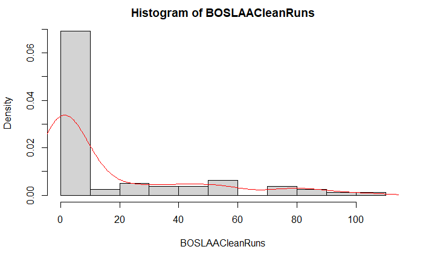

```r
hist(BOSLAACleanRuns, prob= T)
lines(density(BOSLAACleanRuns), col = "red")
```

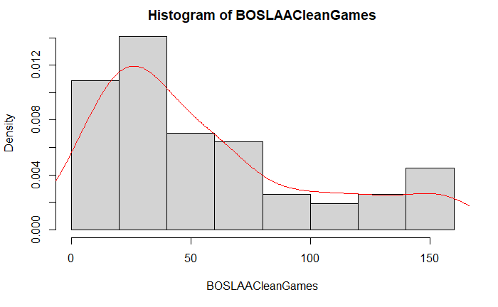

```r
hist(BOSLAACleanGames, prob= T)
lines(density(BOSLAACleanGames), col = "red")
```

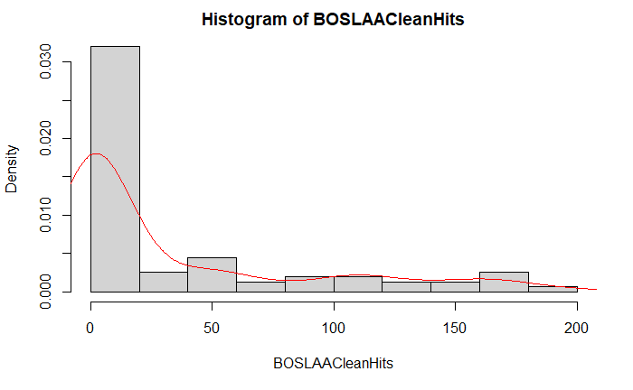

```r
hist(BOSLAACleanHits, prob= T)
lines(density(BOSLAACleanHits), col = "red")
```

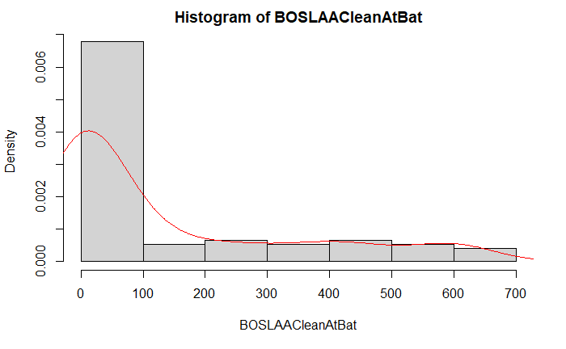

```r
hist(BOSLAACleanAtBat, prob= T)
lines(density(BOSLAACleanAtBat), col = "red")
```

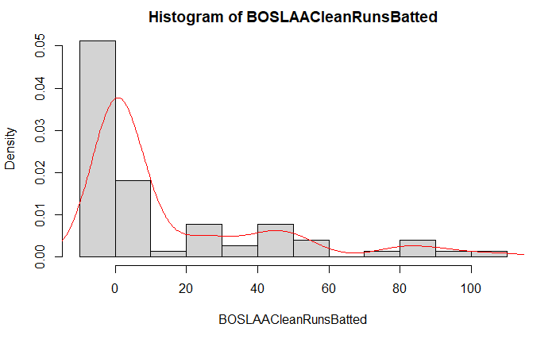

```r
hist(BOSLAACleanRunsBatted, prob= T)
lines(density(BOSLAACleanRunsBatted), col = "red")
```

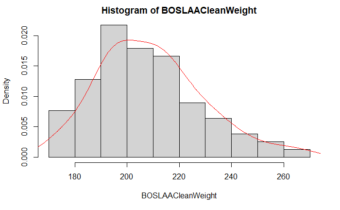

```r
hist(BOSLAACleanWeight, prob= T)
lines(density(BOSLAACleanWeight), col = "red")
```

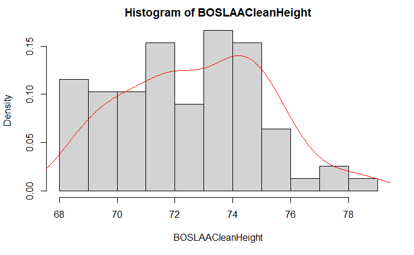

```r
hist(BOSLAACleanHeight, prob= T)
lines(density(BOSLAACleanHeight), col = "red")
```

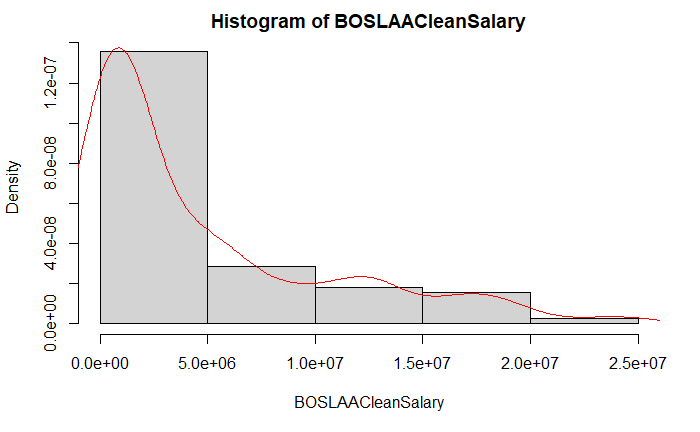

```r
hist(BOSLAACleanSalary, prob= T)
lines(density(BOSLAACleanSalary), col = "red")
```

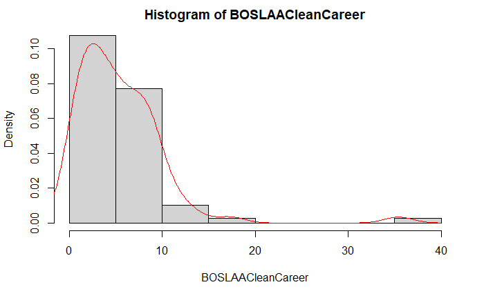

```r
hist(BOSLAACleanCareer, prob= T)
lines(density(BOSLAACleanCareer), col = "red")
```

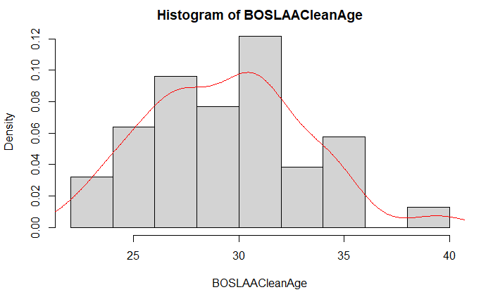

```r
hist(BOSLAACleanAge, prob= T)
lines(density(BOSLAACleanAge), col = "red")
```

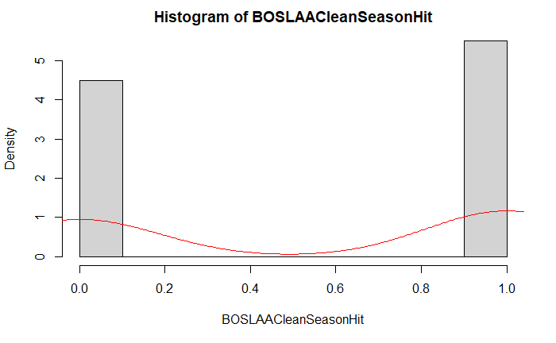

```r
hist(BOSLAACleanSeasonHit, prob= T)
lines(density(BOSLAACleanSeasonHit), col = "red")
```

This is quite interesting, because we have a nice assortment of different kinds of disctributions.

There are many things that instantly stand out which I will be able to test soon. Right now, I will look at the distributions.

Height, weight, and age appear to have binomial distribution. Runs, hits, bats, games, salary, career and at bats all seem to have poisson distribution. This is because evrybody starts at zero. Season hit has a bernouilli distribution.

Now is time to test these.

```r
shapiro.test(BOSLAACleanWeight)
```

```
    Shapiro-Wilk normality test

data:  BOSLAACleanWeight
W = 0.97173, p-value = 0.08002
```

```r
shapiro.test(BOSLAACleanHeight)
```

```
    Shapiro-Wilk normality test

data:  BOSLAACleanHeight
W = 0.96964, p-value = 0.05926
```

```r
shapiro.test(BOSLAACleanAge)
```

```
    Shapiro-Wilk normality test

data:  BOSLAACleanAge
W = 0.98249, p-value = 0.3606
```

Age, weight, and height are normal, as their p-value is over 0.05. The others need to be looked at.

I can also measure the skewness of Runs, hits, runs batted, games, salary, career. They are indeed skewed.

```r
skewness(BOSLAACleanRuns)
```

```
[1] 1.587938
```

```r
skewness(BOSLAACleanHits)
```

```
[1] 1.509163
```

```r
skewness(BOSLAACleanRunsBatted)
```

```
[1] 1.735131
```

```r
skewness(BOSLAACleanAtBat)
```

```
[1] 1.324231
```

```r
skewness(BOSLAACleanGames)
```

```
[1] 0.9760763
```

```r
skewness(BOSLAACleanSalary)
```

```
[1] 1.434319
```

```r
skewness(BOSLAACleanCareer)
```

```
[1] 3.073594
```

## 2.3 Additional insights and issues

*Highlight potential further issues or insights uncovered in 2.2. This might include follow up to findings from your initial EDA. We accept that the boundary between 2.2 and 2.3 is somewhat arbitrary so use your judgement and maximise good structure and readability. (5 marks)*

Seeing as the median is zero in a few graphs, yielding extremely skewed distributions, to remove the zero values would allow me to learn a lot more about the rest. Let’s take a look at Runs and RunsBatted. In fact, it would also be helpful to do the same to Hits and AtBat What you have here is what Nassim Taleb might call a fat-tailed distribution in these cases. This means that given that everybody starts at zero, but the upper limit is theoretically unlimited. What will happen in this case is precicely what is found here.

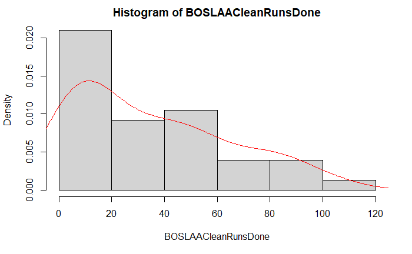

```r
## create new sets removing values =0
BOSLAACleanRunsDone = BOSLAACleanRuns[BOSLAACleanRuns != "0"]
hist(BOSLAACleanRunsDone, prob = T)
lines(density(BOSLAACleanRunsDone), col = "red")
```

```r
summary(BOSLAACleanRunsDone)
```

```
   Min. 1st Qu.  Median    Mean 3rd Qu.    Max.
   3.00    9.00   28.00   35.21   54.50  104.00
```

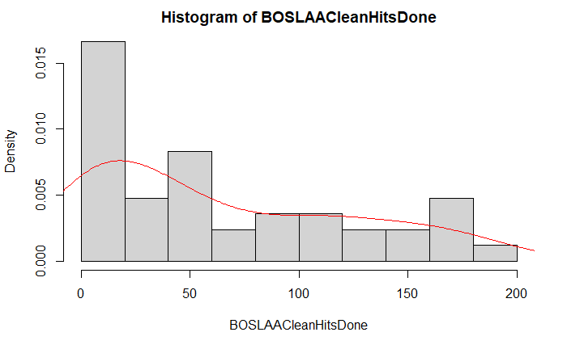

```r
BOSLAACleanHitsDone = BOSLAACleanHits[BOSLAACleanHits != "0"]
hist(BOSLAACleanHitsDone, prob = T)
lines(density(BOSLAACleanHitsDone), col = "red")
```

```r
summary(BOSLAACleanHitsDone)
```

```
   Min. 1st Qu.  Median    Mean 3rd Qu.    Max.
   1.00   12.25   45.00   63.98  110.50  196.00
```

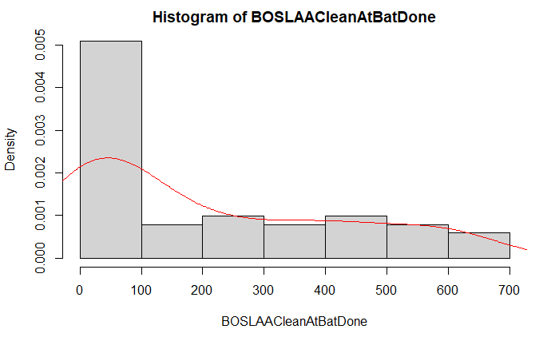

```r
BOSLAACleanAtBatDone = BOSLAACleanAtBat[BOSLAACleanAtBat != "0"]
hist(BOSLAACleanAtBatDone, prob = T)
lines(density(BOSLAACleanAtBatDone), col = "red")
```

```r
summary(BOSLAACleanAtBatDone)
```

```
   Min. 1st Qu.  Median    Mean 3rd Qu.    Max.
    1.0    13.5    97.0   205.5   379.5   630.0
```

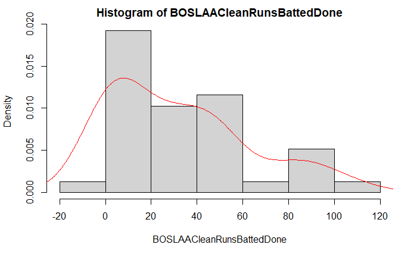

```r
BOSLAACleanRunsBattedDone = BOSLAACleanRunsBatted[BOSLAACleanRunsBatted !="0"]
##This is a very good moment to remove that -4
hist(BOSLAACleanRunsBattedDone, prob = T)
lines(density(BOSLAACleanRunsBattedDone), col = "red")
```

```r
summary(BOSLAACleanRunsBattedDone)
```

```
   Min. 1st Qu.  Median    Mean 3rd Qu.    Max.
  -4.00    4.50   25.00   32.26   48.00  108.00
```

```r
##Another way to do this is to select sums greater than or lower than a certain amount. I will probably to this to analyse those who did not do any runs hits, at bats, or bats.
RunsDoneSkew =  skewness(BOSLAACleanRunsDone)
RunsDoneSkew
```

```
[1] 0.6834338
```

```r
HisDoneSkew = skewness(BOSLAACleanHitsDone)
HisDoneSkew
```

```
[1] 0.6678767
```

```r
AtBatDoneSkew = skewness(BOSLAACleanAtBatDone)
AtBatDoneSkew
```

```
[1] 0.7290642
```

```r
RunsBattedDoneSkew = skewness(BOSLAACleanRunsBattedDone)
RunsBattedDoneSkew
```

```
[1] 0.8119282
```

```r
##
```

```r
BOSLAACleanerRunsBattedDone <- abs(BOSLAACleanRunsBattedDone)
BOSLAACleanerRunsBattedDone
```

```
 [1]  77  81  43  29   3  25  16  45   1   3   1  40   7 108  42  53  47   4   5  25
[21]   4  44  83   2  51   4  56  49   9  34  21  23   5   1  95   7  90   3  30
```

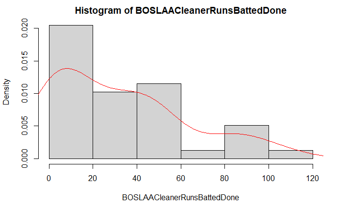

```r
hist(BOSLAACleanerRunsBattedDone, prob = T)
lines(density(BOSLAACleanerRunsBattedDone), col = "red")
```

```r
summary(BOSLAACleanerRunsBattedDone)
```

```
   Min. 1st Qu.  Median    Mean 3rd Qu.    Max.
   1.00    4.50   25.00   32.46   48.00  108.00
```

```r
RunsBattedDoneSkew = skewness(BOSLAACleanerRunsBattedDone)
RunsBattedDoneSkew
```

```
[1] 0.8332996
```

The cleaner version shows that this is clearly not a normal distribution.

# 3. Modelling

## 3.1 Build a model for player salary

*Given the research question (i.e., the target attribute of salary) outline an analysis plan that incorporates/references any findings from the data cleaning (1.3) and EDA (2.2) (5 marks). Use R to build a suitable model (10 marks).*  
*NB Submissions where suitable models do not have good fit due to the nature of the data will not be penalised.*

The first thing that I can do is look at all of the collelants.This is quite good, because I can see in one shot what appears to affect what. Some of this might be misleading. For example, height and weight seem to have nothing to do with salary. This is to do with the fact that height and weight have a normal distribution. There could be an ideal height and weight, and this is not indicated here. The strongest relationship seems to do ith age and career length.

```
data in column(s) 'playerID', 'teamID.x', 'birthDate', 'bats' are not numeric and were ignored
```

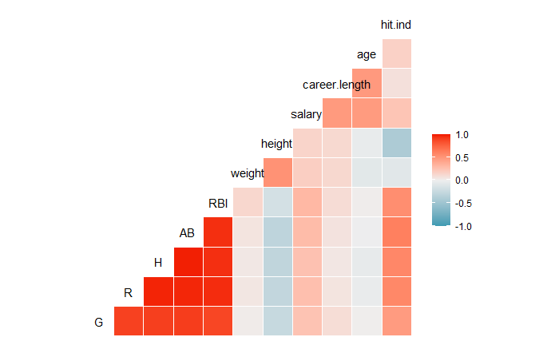

```r
ggcorr(BOSLAAClean)
```

I want to see the correlates between each variable and player salary. Then, within that, see wether any of those items move win or against one another. Such as career length and age. or runs and bats. This is to see whether I am correct to assume that these elements might be connected. ANOVA and ANCOVA will be useful for finding a lot of information in one go. Another thing is that I will go one by one and remove the weakest correlants.

```r
step(league)
```

[output not shown]

For example, a bloc plot will be useful for the season hit statistic in particular.

```r
ggplot(BOSLAAClean, aes(x=BOSLAACleanBats, y=BOSLAACleanSalary)) + geom_boxplot()
ggplot(LAAClean, aes(x=LAACleanBats, y=LAACleanSalary)) + geom_boxplot()
ggplot(BOSClean, aes(x=BOSCleanBats, y=BOSCleanSalary)) + geom_boxplot()
```

[output not shown]

What about career lenght, and age? What about birthmonth and age? I will also look at birth month and salaray.The reason for this is that there are many studie swhich show that the birth month of a person can have a high impact on their sports performance. This is due to how the school year functions. I will also check the year, while I’m at it. For this to work, I need to extract the month from the birth date, and then turn it into a factor so that it they can be separate like in the batting box plot above. The same will be done with season hit which has only two possible answers, 0 and 1.

```r
BOSLAACleanMonth = month(BOSLAACleanBirth)

BOSLAACleanMonthFactor = factor(BOSLAACleanMonth)
levels(BOSLAACleanMonthFactor)
ggplot(BOSLAAClean, aes(x=BOSLAACleanMonthFactor, y=BOSLAACleanSalary)) + geom_boxplot()

BOSLAACleanYear = year(BOSLAACleanBirth)

BOSLAACleanYearFactor = factor(BOSLAACleanYear)
levels(BOSLAACleanYearFactor)
ggplot(BOSLAAClean, aes(x=BOSLAACleanYearFactor, y=BOSLAACleanSalary, prob = T)) + geom_boxplot()
```

[output not shown]

```r
BOSLAACleanSeasonHitFactor = factor(BOSLAACleanSeasonHit)
levels(BOSLAACleanSeasonHitFactor)
ggplot(BOSLAAClean, aes(x=BOSLAACleanSeasonHitFactor, y=BOSLAACleanSalary)) + geom_boxplot()
```

[output not shown]

Obvious things to test whether they correlate are career length and salary, especially since we saw that the birth year seems linked. We need to see whether it is only a function of length, or seniority.

```r
##testing correlations is important here
cor(BOSLAACleanAge, BOSLAACleanSalary, method = c("pearson", "kendall", "spearman"))
cor.test(BOSLAACleanAge, BOSLAACleanSalary, method=c("pearson", "kendall", "spearman"))
cor(BOSLAACleanCareer, BOSLAACleanSalary, method = c("pearson", "kendall", "spearman"))
cor.test(BOSLAACleanCareer, BOSLAACleanSalary, method=c("pearson", "kendall", "spearman"))
```

[output not shown]

What we find here is pretty amazing. They have very similar correlations. We can learn several things. One is that the longer a person plays, the more they will make, and it does not matter what year they start in.

This is very interesting. Now that we see that the longer someone has played indicates a higher salary, what about performance during the season itself? It might seem obvious that performance and salary would correlate, but not necessarily. For instance, studies have shown that athletes’ performance can dip after transferring from one team to another. This transfer usually follows an offer of a higher salary. There was another stuyd in Israel as noted by Judea Pearl in the Book of Why about the effect of praise on soldier performances. It seemed to have an inverse correlatin, but this was due to some form of mean regression. Because some players will never bat or run because players on a baseball team sometimes have specialisations, all those with a zero value will be removed. This is a complicated decision because some of the players with zero will be unnecessary, others will be necessary. The proportion of these is unknown without knowing more about each individual player. It is important to compare like-for-like. It would not be correct to measure salary on batting performance on someone who is not on the team to bat, for example. They are being paid for something else otherwise undefined.

```r
#create version of only what was done

# another version could perhaps include the version with the zero values to illustrate their effect

HitsLM = (lm(formula = BOSLAACleanHits ~ BOSLAACleanSalary))
plot(HitsLM)
GamesLM = (lm(formula = BOSLAACleanGames ~ BOSLAACleanSalary))
plot(GamesLM)
RunsLM = (lm(formula = BOSLAACleanRuns ~ BOSLAACleanSalary))
plot(RunsLM)
RunsBattedLM = (lm(formula = BOSLAACleanRunsBatted ~ BOSLAACleanSalary))
plot(RunsBattedLM)
```

[output not shown]

The next thing that I want to look at is height and weight. Is there an ideal height or weight?

```r
HeightLM = lm(formula = BOSLAACleanHeight ~ BOSLAACleanSalary)
plot(HeightLM)
WeightLM = lm(formula = BOSLAACleanWeight ~ BOSLAACleanSalary)
plot(WeightLM)
#create model comparing heigth and weright - scatter plot?
```

[output not shown]

Some of these look radically different, while others do not. I can test this by looking at the various distributions.